# HW1

Abigail Salle

2022-10-02

Main Idea Questions:  
1. Supervised learning tries to accurately predict or estimate future responses based on given input and output data. The data Y is the supervisor.  
Unsupervised learning means that the observations X have no associated response Y. We still can find relationships between X’s.  
The difference is the presence or absence of response data Y. In both we are learning patterns, but in unsupervised learning we just won’t know the true pattern in the end.  
2. Regression models have quantitative / numerical outcomes while classification have qualitative / categorical outcomes.  
For machine learning, this means that different problems require different methods and models. Also, regression models are continuous and classification models are noncontinuous.  
3. Two common metrics for regression problems are mean square error and r square.  
Two common metrics for classification problems are accuracy and confusion matrix.  
4. Descriptive models: Models intended to visually emphasize the trends in data.  
Predictive models: Combination of models to predict overall best with least amount of error possible.  
Inferential models: Shows the relationship between outcome and predictors to see which features in particular are significant.  
5. Mechanistic assumes a parametric form while empirically driven has no assumptions on f.  
They are similar in the chance of possible overfitting and are different in flexibility and requirement of observation size.  
Mechanistic is easier to understand. Linear is easier to explain and the more layers and parameters added is more complicated which is why empirically driven is harder.  
The Bias-Variance tradeoff relates to ML models because a mechanistic model will have high bias and low variance but an empirical will have low bias and high variance. In a perfect world we want low both, so we must find models that best manages the two, which is the tradeoff.  
6. “Given a voter’s profile/data, how likely is it that they will vote in favor of the candidate?”  
This is overall prediction and wants accuracy with least error, so it would be predictive.  
“How would a voter’s likelihood of support for the candidate change if they had personal contact with the candidate?”  
This has to do with one particular feature (knowing the candidate) so it would be inferential.  
Exploratory Data Analysis:

```r
library(tidyverse)
head(mpg)
```

```
## # A tibble: 6 × 11
##   manufacturer model displ  year   cyl trans      drv     cty   hwy fl    class
##   <chr>        <chr> <dbl> <int> <int> <chr>      <chr> <int> <int> <chr> <chr>
## 1 audi         a4      1.8  1999     4 auto(l5)   f        18    29 p     compa…
## 2 audi         a4      1.8  1999     4 manual(m5) f        21    29 p     compa…
## 3 audi         a4      2    2008     4 manual(m6) f        20    31 p     compa…
## 4 audi         a4      2    2008     4 auto(av)   f        21    30 p     compa…
## 5 audi         a4      2.8  1999     6 auto(l5)   f        16    26 p     compa…
## 6 audi         a4      2.8  1999     6 manual(m5) f        18    26 p     compa…
```

Question 1:

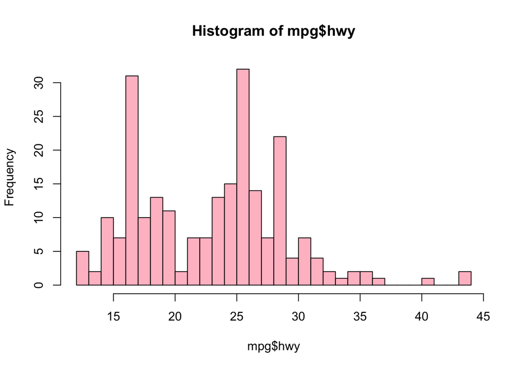

```r
hist(mpg$hwy, col="pink", breaks=30)
```

I see that the highest frequency of highway miles per gallon is at 25 and lowest are around 38-43. It appears to be right skewed which means frequency is higher at lower mpg. There are 3 main peeks and a few empty.  
Question 2:

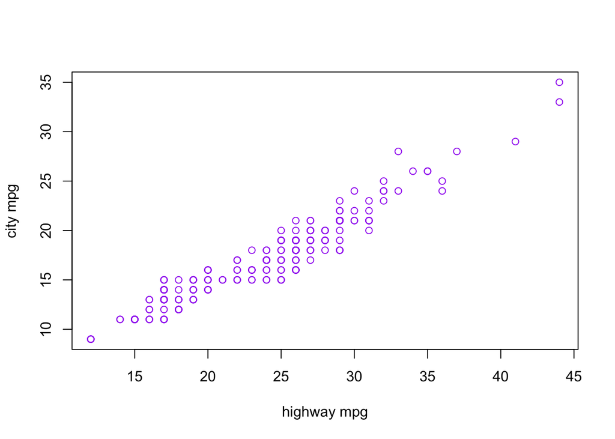

```r
x <- mpg$hwy
y <- mpg$cty
plot(x,y, col="purple", xlab="highway mpg", ylab="city mpg")
```

I see many points going in a pattern starting from origin and moving up and to the right. The relationship appears to be that when highway miles per gallon increases, city miles per gallon also increases. It looks like a relatively straight line could pass through most points, giving it a relatively strong positive correlation.  
Question 3.

```r
table(mpg$manufacturer)
```

```
##
##       audi  chevrolet      dodge       ford      honda    hyundai       jeep
##         18         19         37         25          9         14          8
## land rover    lincoln    mercury     nissan    pontiac     subaru     toyota
##          4          3          4         13          5         14         34
## volkswagen
##         27
```

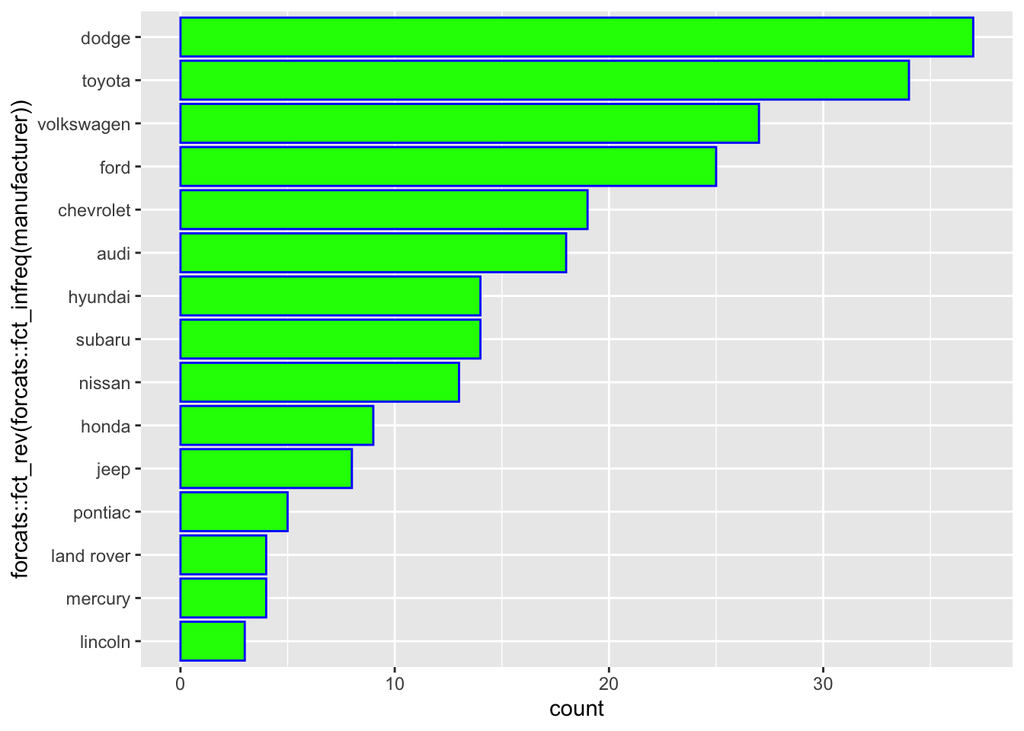

```r
ggplot(data=mpg) + geom_bar(mapping=aes(y= forcats::fct_rev(forcats::fct_infreq(manufacturer))),col="blue", fill="green")
```

Dodge produced the most cars and Lincoln produced the least cars.  
Question 4:

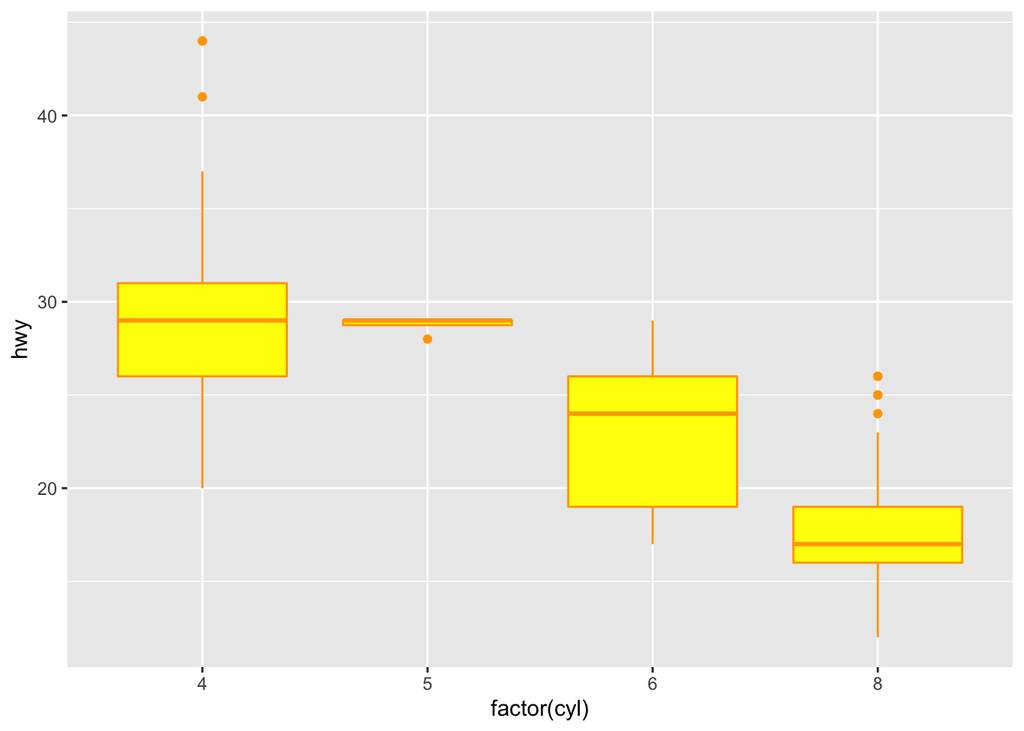

```r
ggplot(mpg, aes(x=factor(cyl), y=hwy))+ geom_boxplot(col="orange", fill="yellow")
```

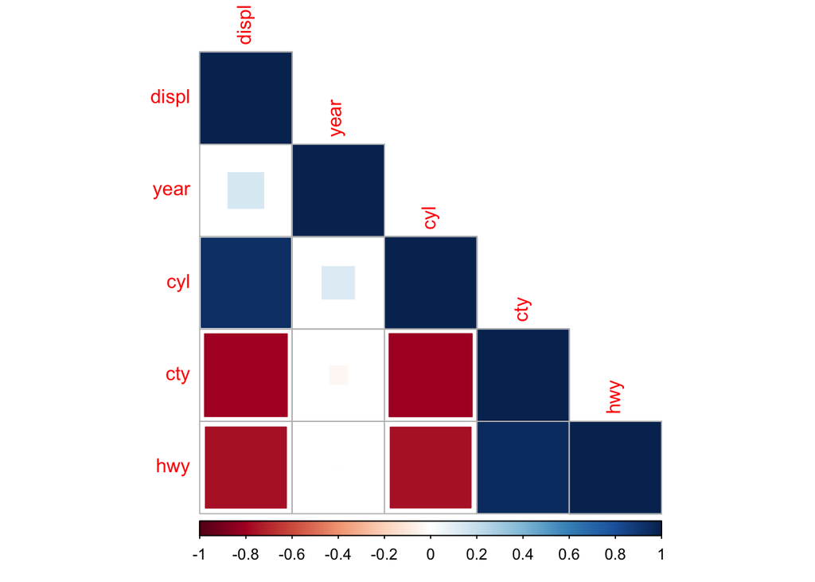

```r
library("corrplot")
mpg2 <- mpg[,-c(1,2,6,7,10,11)]
 M <- cor(mpg2)
corrplot(M, method='square', type='lower')
```

There are strong positive correlations between highway & city mpg and between number cylinders & engine displacement.  
Highway mpg has strong negative correlation with cylinders and displacement. City mpg has negative correlation with cylinders and displacement also.  
These relationships do make sense to me but what surprises me most is year not correlating with anything.